# pres slides

## Состав команды

- Антон Сметанин
- Максим Холодилин
- Илья Сагамонов
- Даниил Хроменков
- Дмитрий Арефьев

## Пункт 0: Составим план действий

1. Получить котировки акций
2. Объединить все цены в одну таблицу по дате закрытия
3. Вычислить еженедельную доходность
4. Проверить гипотезу о нормальном распределении
5. Вычислить интервальные оценки параметров
6. Проверить гипотезу о равенстве коэффициента корреляции 0
7. Трансформировать матрицу ковариации согласно результатам проверки гипотезы
8. Решить задачу Тобина и получить оптимальный портфель

## Импортируем класс с решением

```python
%run Tobin_portfolio.ipynb
```

## Инициализируем объект класса со следующими параметрами:

```python
start_portfolio = Get_investment_portfolio("./data",portfolio_income=40,
                                           unrisk_income=3.04,outliers=True,
                                           start_cash = 1000000,
                                           confidence_level_interval=0.95,
                                           confidence_level_normal=0.01)
```

## Пункт 1: Обоснование выбора активов

### TSM

```
-  Taiwan Semiconductor производит и поставляет на рынок интегральные схемы, которые используют при производстве компьютеров,средств связи, автомобилестроении и промышленном оборудовании. В данный момент рынок связи(5G), электрокаров и новых технологий активно развивается. Генерирую огромный спрос на интегральные схемы. Заводов способных обеспечивать производство больших партий микросхем не так много, на данный момент в тройку лидеров входят intel, samsung и TSM. Но именно TSM является самым крупным контрактным производителем схем
```

### AMD

```
-  Advanced Micro Devices — американский производитель интегральной микросхемной электроники, один из крупнейших производителей центральных процессоров, графических процессоров и адаптеров, материнских плат и чипсетов. Компания также активно развивает технологии машинного обучения, искусственного интеллекта и блокчейна.А так как эти направления являются одними из наиболее передовых технологий в современном мире, компания является достаточно перспективной для покупки
```

### YNDX

```
-  Яндекс - одна из крупнейших информационных компаний в России, которая располагает различными сервисами в самых разных сферах жизни граждан. Так же у компании присутствуют продукты нацеленные на международный рынок. Эта компания развивается в различных сферах которые будут востребованы еще долгое время поэтому ее акции будут перспективны при долгосрочном владении
```

### FDX

```
- FedEx - одна из крупнейших компаний осуществляющих логистические услуги. Да полного снятия антивирусных ограничений компании предоставляющие услуги доставки, работают в авральном режиме. Поэтому можно предположить, что пока вопрос вируса все еще стоит достаточно остро, обороты компании будут только расти
```

### NFLX

```
- Netflix — американская развлекательная компания, поставщик фильмов и сериалов на основе потокового мультимедиа. Является не только онлайн платформой, оказывающей услуги стриминга медиаматериалов, но так же и одним из основным  их производителей. В данный момент онлайн кинотеатры это один из самых  перспективных рынков
```

### FIVEDR

```
- X5 Retail Group — российская рознично-торговая компания, управляющаяся продуктовыми торговыми сетями «Пятёрочка», «Перекрёсток», «Карусель». Доля по выручке на российском рынке продуктовой розницы — 11,5 %, 3-я по выручке российская компания.
```

### GOOGL

```
- Google — одна из самых крупных в мире поисковых систем интернета, принадлежащая корпорации Google Inc. Основана в 1998 году Ларри Пейджем и Сергеем Брином. Первая по популярности система, обрабатывает 41 млрд 345 млн запросов в месяц, индексирует более 25 миллиардов веб-страниц
```

### MU

```
- Micron Technology — американская транснациональная корпорация, известная своей полупроводниковой продукцией, основную часть которой составляют чипы памяти DRAM и NAND, флеш-память, SSD-накопители, а также датчики CMOS
```

### ALRS

```
- Алроса — российская группа алмазодобывающих компаний, занимающая лидирующую позицию в мире по объёму добычи алмазов.  В сферу ее деятельности входят: разведка месторождений, добыча, обработка и последующая продажа алмазного сырья. На Алросу приходится 95% добычи алмазов в РФ, а доля на мировом рынке достигает 25%. Основную деятельность ведет в Якутии, а запасов компании, которые составляют треть от общемировых, будет достаточно на поддержание деятельности в ближайшие 20 лет. Поэтому данная компания может позволить выделять средства на развитие процессов компании и разработку новых технологий, ведущих в перспективе к увеличению прибыли и уменьшению расходов
```

### NVDA

```
- Nvidia — американская технологическая компания, разработчик графических процессоров и систем на чипе.
NVIDIA находится в центре многих тенденций, которые обещают быть от огромных до огромных.
Вот основные из них:
    - Компьютерные игры / киберспорт
    - Искусственный интеллект (ИИ)
    - Облачные вычисления
    - Высокопроизводительные вычисления (HPC)
    - Дроны
```

## Пункт 2: Обоснование применимости подходов к статистической оценке атрибутов портфеля и активов

### Список атрибутов, которые были оценены или получены в нашей работе, на основании выборочных данных

- Точечные оценки:
  - Доходности активов
  - Рисков активов
- Интервальные оценки:
  - Интервальная оценка доходностей активов
  - Интервальная оценка рисков активов
- Матрица корреляции активов
- Матрица ковариации активов

### Точечные оценки

- Точечной оценкой ожидаемой доходности является выборочное среднее, так как оно является — несмещённой оценкой теоретического среднего
- Точечная оценка риска актива - выборочное стандартное отклонение

### Интервальные оценки

- Интервальной оценкой доходности является интервальная оценка математического ожидания нормально распределенного количественного признака Х по выборочной средней
- Интервальной оценкой риска является интервальная оценка среднеквадратичного отклонения нормально распределенного количественного признака Х по выборочному среднему

##### Для интервальной оценки атрибутов необходимо убедиться в том, что выборки пришли к нам из нормального распределения

### Для того что бы убедиться, что выборка пришла к нам из нормального распределения воспользуемся проверкой гипотезы о нормальном распределении по критерию Пирсона

- Для этого воспользуемся библиотекой scipy, в которой реализована данная гипотеза в методе normaltest()
- Принцип работы данного метода заключается в том, что получая на вход выборку от возвращает p-value, т.е. вероятность ошибки первого рода, которое мы сравниваем с уровнем значимости устанавливаемым при инициализации класса. И на основании этого сравнения мы принимаем решение отвергнуть нулевую гипотезу или нет.
- В данном случае гипотезы будут следующие:

  $$ \begin{cases} H_0: \textrm{Выборка пришла к нам из нормального распределения}\\ H_1: \textrm{Выборка пришла к нам не из нормального распределения} \end{cases}\,. $$

```python
def __check_normaltest(self):
        """
        Метод отвечающий за провекру гипотеза на нормальность выборки
        """
        # Инициализируем словарь для акций, прошедших проверку
        self.pass_shares = {}
        # Инициализируем словарь для акций, не прошедших проверку
        self.fail_shares = {}
        # Переберем все акции из нашей таблицы доходности
        for label in self.income_data.columns:
            # Получим для каждой выборки p-value
            _, p_value = st.normaltest(self.income_data[label])
            # Сравним найденное p-value с уровнем значимости
            if round(p_value,2) < self.confidence_level_normal:
                self.fail_shares[label] = p_value
            else:
                self.pass_shares[label] = p_value
        # Проверим все ли акции прошли проверку
        if len(self.pass_shares) >= 10:
            print("Все отлично, минимальное количество акций прошло проверку")
            top_best_shares = (self.income_data.describe()
                                 .loc["mean",list(self.pass_shares.keys())]
                                 .sort_values(ascending = False)
                                 .head(len(self.pass_shares))
                                 .index.tolist())
            self.income_data = self.income_data.loc[:,top_best_shares]
        else:
            # Выведем акции и их p-value, которые не прошли проверку
            print("Не все акции прошли проверку. Вот неподходящие акции")
            print(self.fail_shares,end = "\n\n")
```

### Посмотрим, результаты работы данного метода

```python
print("Акции, прошедшие проверку гипотезой")
display(start_portfolio.pass_shares.keys())
print("Акции, не прошедшие проверку гипотезой",start_portfolio.fail_shares,end = "\n\n")
```

```
Акции, прошедшие проверку гипотезой
```

```
dict_keys(['Income_TSM', 'Income_ALRS', 'Income_AMD', 'Income_NVDA', 'Income_YNDX', 'Income_FDX', 'Income_NFLX', 'Income_FIVEDR', 'Income_GOOGL', 'Income_MU'])
```

```
Акции, не прошедшие проверку гипотезой {}
```

Как мы можем видеть все акции прошли проверку, следовательно мы можем сказать, что вероятнее всего выборки еженедельных доходностей выбранных акций пришли к нам из нормального распределения. Данная информация позволяет нам воспользоваться интервальной оценкой. Так же мы сможем воспользоваться гипотезой о равенстве коэффициента корреляции 0, который мы разберем подробнее чуть позже

### Теперь вернемся к оценкам параметров

#### Точечные оценки

```python
display(start_portfolio.income_data.describe()
        .loc[["mean","std"],start_portfolio.income_data.columns[:5]])
display(start_portfolio.income_data.describe()
        .loc[["mean","std"],start_portfolio.income_data.columns[5:]])
```

|  | Income_AMD | Income_NVDA | Income_TSM | Income_MU | Income_YNDX |
| --- | --- | --- | --- | --- | --- |
| mean | 80.298212 | 76.706013 | 67.733849 | 50.096409 | 45.808007 |
| std | 370.983103 | 305.172567 | 218.891127 | 331.717692 | 233.561472 |

|  | Income_GOOGL | Income_FIVEDR | Income_NFLX | Income_FDX | Income_ALRS |
| --- | --- | --- | --- | --- | --- |
| mean | 34.197323 | 27.635334 | 27.430591 | 25.969170 | 6.147629 |
| std | 203.739396 | 240.914667 | 264.489478 | 309.960386 | 228.862832 |

#### Интервальные оценки

##### Рассмотрим теоретическую составляющую интервальной оценки стандартного отклонения

В теории мы можем найти следующие формулы для нахождения интервальной оценки стандартного отклонения. Для нахождения значения значения Хи квадрат воспользуемся библиотекой scipy

#### Рассмотрим теоретическую составляющую интервальной оценки математического ожидания

В теории задачника Гмурмана мы можем найти следующие формулы для нахождения интервальной оценки математического ожидания $$ x_в - t_y(s/\sqrt(n)) < a < x_в + t_y(s/\sqrt(n))\\ \textrm{где}\\ t_y - \textrm{находят по таблице Стьюдента}\\ x_в - \textrm{выборочное среднее}\\ s/\sqrt(n) - \textrm{Стандартная ошибка}\\ $$

Для построения интервальной оценки доходности активов воспользуемся библиотекой scipy, в которой реализован метод interval.

В которой необходимо передать следующие параметры:

```
- уровень значимости
- степень свободы равная количеству элементов выборки -1
- выборочное среднее
- стандартную ошибку
```

```python
def __get_confidence_interval(self):
        # Инициализируем индексы, которые в дальнейше преобразуем в мультииндекс
        pre_index = [("estimate_mean","left_side"),
                     ("estimate_mean","right_side"),
                     ("estimate_std","left_side"),
                     ("estimate_std","right_side")]
        list_index = np.empty(len(pre_index), dtype=object)
        list_index[:] = pre_index
        index = pd.MultiIndex.from_tuples(list_index)
        # Инициализируем фрейм, в который будем записывать найденные оценки
        self.period_estimate_table = pd.DataFrame(index = index)
        for label in self.income_data.columns:
            # Вычислим оценку среднего
            mean_estimate =  st.t.interval(self.confidence_level_interval,
                                           len(self.income_data[label])-1,
                                           self.income_data[label].mean(),
                                           self.income_data[label].sem())
            # Дополним таблицу, найденными знаениями
            self.period_estimate_table.loc[list_index[0],label] = mean_estimate[0]
            self.period_estimate_table.loc[list_index[1],label] = mean_estimate[1]
            # Вычислим оценку отклонения и определим уровни
            p1 = (1 + self.confidence_level_interval)/2
            p2 = (1 - self.confidence_level_interval)/2
            # Найдем, интересующие нас значения
            value1 = chi2.ppf(p1, self.income_data.shape[0])
            value2 = chi2.ppf(p2, self.income_data.shape[0])
            # Дополним таблицу, найденными знаениями
            self.period_estimate_table.loc[list_index[2],label] = round((
                (self.income_data[label].std()*(self.income_data.shape[0] - 1)/value1)**0.5),2)
            self.period_estimate_table.loc[list_index[3],label] = round((
                (self.income_data[label].std()*(self.income_data.shape[0] - 1)/value1)**0.5),2)
```

```python
display(start_portfolio.period_estimate_table
        .loc[:,start_portfolio.income_data.columns[:5]])
display(start_portfolio.period_estimate_table
        .loc[:,start_portfolio.income_data.columns[5:]])
```

[output not shown]

[output not shown]

### Обработка матрицы ковариации

Снова обратимся к учебнику Гмурмана и найдем там теоретический материал, описывающий проверку гипотезы о значимости выборочного коэффициента корреляции. Проверим нулевую гипотезу о равенстве равенстве 0 генерального коэффициента корреляции. Альтернативная гипотеза: генеральный коэффициент корреляции не равен 0, т.е.

$$ \begin{cases} H_0: \textrm{Генеральный коэффициент корреляции} = 0\\ H_1: \textrm{Генеральный коэффициент корреляции} \not= 0 \\ \end{cases} $$

$\textrm{Для этого необходимо найти и сравнить наблюдаемое и критическое значения, где}$

$T_{набл} = \frac{r_в\sqrt{n-2}}{\sqrt{1-r_{в}^{2}}}\\$ $t_{крит}(\alpha,n-2) - \textrm{находят по таблице критических точек Стьдента}$

$\textrm{Если }|T_{набл}| < t_{крит}\textrm{ то нет оснований отвергать нулевую гипотезу}$

$\textrm{Если }|T_{набл}| > t_{крит}\textrm{ то нулевую гипотезу отвергают}$

#### Посмотрим, как это было реализовано в коде

```python
def __get_corr_mask(self):
        """
        Метод, который проверят гипотезу на равенство коэффициента коррелции равном 0
        """
        # Инициализируем пустой массив, а котором будет хранить маску
        self.corr_mask = []
        n = self.income_data.describe().loc["count"][0]
        # Переберем все коэффициенты
        for array, i in zip(self.income_data.corr().values,range(0,len(self.income_data.corr()))):
                pre_corr = []
                for ind in range(len(array)):
                    if ind != i:
                        # Найдем наблюдаемое значение
                        t_nabl = (array[ind]*(n-2)**0.5)/(1-array[ind]**2)**0.5
                        # Сравним наблюдаемое значение с критическим
                        if st.t.ppf(1-0.05/2, n-2) < abs(t_nabl):
                            pre_corr.append(0)
                        else:
                            pre_corr.append(1)
                    else:
                        pre_corr.append(1)
                self.corr_mask.append(pre_corr)
```

##### Пример результата работы данного метода

```
[[1, 0, 0, 0, 0, 0, 1, 0, 0, 0],
 [0, 1, 0, 0, 0, 0, 1, 0, 0, 0],
 [0, 0, 1, 0, 1, 0, 1, 0, 0, 0],
 [0, 0, 0, 1, 0, 0, 1, 0, 0, 0],
 [0, 0, 1, 0, 1, 0, 0, 0, 0, 0],
 [0, 0, 0, 0, 0, 1, 1, 0, 0, 0],
 [1, 1, 1, 1, 0, 1, 1, 1, 1, 1],
 [0, 0, 0, 0, 0, 0, 1, 1, 0, 0],
 [0, 0, 0, 0, 0, 0, 1, 0, 1, 0],
 [0, 0, 0, 0, 0, 0, 1, 0, 0, 1]]
```

#### После этого мы форматируем матрицу ковариации согласно найденной выше матрицы

Это реализовано следующим образом

```python
def __format_cov_matrix(self):
        """
        Метод, обрабатывающий матрицу ковариации, согласно найденной маске корреляции
        """
        self.total_cov = []
        for array_corr,array_cov in zip(self.corr_mask,self.income_data.cov().values):
            pre_cov = []
            for i in range(len(array_corr)):
                if array_corr[i] == 1:
                    pre_cov.append(array_cov[i])
                else:
                    pre_cov.append(0)
            self.total_cov.append(pre_cov)
```

### На этом с подготовка данных заканчивается и мы переходим к самому главному, задаче Тобина

Формализуем задачу: Для нахождения оптимального портфеля необходимо решить следующую систему: $$ \begin{cases} \sum_{i,j=1}^{n} x_{i}x_{j}\sigma_{ij} \rightarrow min\\ x_{0}a_{0} + \sum_{i=1}^{n} x_{i}a_{i} = a_{p}\\ x_{0} + \sum_{i=1}^{n} x_{i} = 1\\ \end{cases} $$

Выразим x_0 из последнего уравнения и подставим его в предпоследнее уравнение:

$x_{0} = 1 - \sum_{i=1}^{n} x_{i}\\$ $\sum_{i=1}^{n} (a_{i}-a_{0})x_{i} = (a_{p}-a_{0})$

Решим задачу методом неопределенных множителей Лагранжа. Тогда функция Лагранжа будет иметь вид:

$L = \sum_{i,j=1}^{n} x_{i}x_{j}\sigma_{ij} + 2\lambda (\sum_{i=1}^{n} (a_{i}-a_{0})x_{i} = (a_{p}-a_{0}))$

В точке экстремума частные производные функции Лагранжа по всем переменным $x_i$ и $\lambda$ равны нулю, поэтому:

$$ \begin{cases} \frac{\delta L}{\delta x_{i}} = 2(\sum_{j=1}^{n} \sigma_{ij}x_{j} + \lambda(a_{i}-a_{0})) = 0\\ \frac{\delta L}{\delta \lambda} = 2(\sum_{i=1}^{n} (a_{i}-a_{0})x_{i} = (a_{p}-a_{0}) = 0 \end{cases} $$

Что в свою очередь равносильно

$$ \begin{cases} VX + \lambda(A-a_{0}I)= 0\\ (A-a_{0}I)^{T}X = a_{p}-a_{0} \end{cases} $$

Где

$V - \textrm{Матрица ковариаций рисковой части}$

$X - \textrm{Вектор долей капитала, вкладываемого в актив}$

$A - \textrm{Вектор доходностей рисковой части портфеля}$

$I - \textrm{единичный вектор-столбец}$

Из первого уравнения системы находим

$X = -\lambda V^{-1}(A-a_{0}I)$

Подставим его во второе и получим:

$\lambda = -\frac{(a_{p}-a_{0})}{(A-a_{0}I)^{T}V^{-1}(A-a_{0}I)}$

Введем обозначение:

$D = (A-a_{0}I)^{T}V^{-1}(A-a_{0}I)$

Получим

$\lambda = -\frac{(a_{p}-a_{0})}{(A-a_{0}I)^{T}V^{-1}(A-a_{0}I)} = -\frac{(a_{p}-a_{0})}{D}$

Теперь подставим полученную лямбду в уравнение, где мы выражали вектор долей и получим

$X = \frac{(a_{p}-a_{0})}{(A-a_{0}I)^{T}V^{-1}(A-a_{0}I)}V^{-1}(A-a_{0}I)$

#### Теперь, когда мы вывели итоговую формулу, можно реализовать метод на ее основе

```python
def __solve_Tobin(self):
        """
        Метод, решиающий задачу Тобина
        """
        # Получаем обратную матрицу ковариаций
        V_reverse = np.linalg.inv(self.total_cov)
        # Получаем вектор доходностей активов
        incomes_vector = self.income_data.describe().loc["mean",:].values
        # Преобразуем вектор доходностей с учетом безрискового актива
        ready_vector = incomes_vector - self.unrisk_income*np.ones(len(incomes_vector))
        # Решаем уравнение Тобина
        D = (ready_vector.T@V_reverse)@ready_vector
        self.portfolio_frac = (
            ((self.portfolio_income-self.unrisk_income)/D).reshape(1,)*V_reverse@ready_vector)

        portfolio = {label[len(self.add_income_text):]:round(frac,4)
                     for label,frac in zip(self.income_data.columns,self.portfolio_frac)}

        portfolio["unrisk"] = round(1- sum(portfolio.values()),4)
        self.value_portfolio = {key:item*self.start_cash for key,item in portfolio.items()}

        print("В долях")
        print(portfolio,end = "\n\n")
        print("В рублях из ",sum(self.value_portfolio.values()))
        print(self.value_portfolio,end = "\n\n")

        return(portfolio)
```

## Пункт 3: Составим портфель

```python
start_portfolio = Get_investment_portfolio("./data",portfolio_income=40,
                                           unrisk_income=3.04,outliers=True,
                                           start_cash = 1000000,
                                           confidence_level_interval=0.95,
                                           confidence_level_normal=0.01,
                                           base_cash=1000000)
start_frac = start_portfolio.fit_trainsform()
```

```
['TSM.csv', 'ALRS.csv', 'AMD.csv', 'NVDA.csv', 'YNDX.csv', 'FDX.csv', 'NFLX.csv', 'FIVEDR.csv', 'GOOGL.csv', 'MU.csv']

Все отлично, минимальное количество акций прошло проверку

Составленный портфель Тобина:
В долях
{'AMD': 0.075, 'NVDA': 0.1085, 'TSM': 0.1689, 'MU': 0.0582, 'YNDX': 0.0807, 'GOOGL': 0.1037, 'FIVEDR': 0.0431, 'NFLX': 0.0467, 'FDX': 0.0272, 'ALRS': 0.0004, 'unrisk': 0.2876}

В рублях из  1000000.0
{'AMD': 75000.0, 'NVDA': 108500.0, 'TSM': 168900.0, 'MU': 58200.0, 'YNDX': 80700.0, 'GOOGL': 103700.0, 'FIVEDR': 43100.0, 'NFLX': 46700.0, 'FDX': 27200.0, 'ALRS': 400.0, 'unrisk': 287600.0}
```

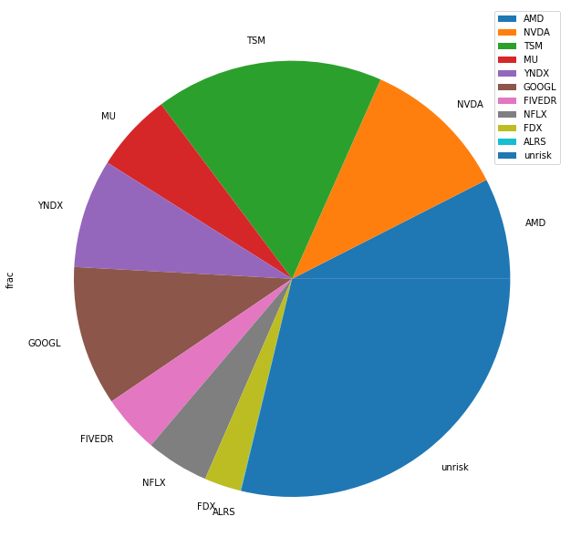

```python
df = pd.DataFrame(data = start_frac.values(),
                  index=start_frac.keys())
df.columns = ["frac"]
plot = df.plot.pie(y='frac', figsize=(15, 11))
```

### Проведем первый пересмотр портфеля

```python
first_rebalance = Get_investment_portfolio("./data_one",portfolio_income=40,
                                           unrisk_income=3.04,outliers=True,
                                           start_cash = 1000000,
                                           confidence_level_interval=0.95,
                                           confidence_level_normal=0.01,
                                           last_income=True,start_portfolio=start_frac,
                                           base_cash=1000000)
```

```python
first_rebalance_frac = first_rebalance.fit_trainsform()
```

[output not shown]

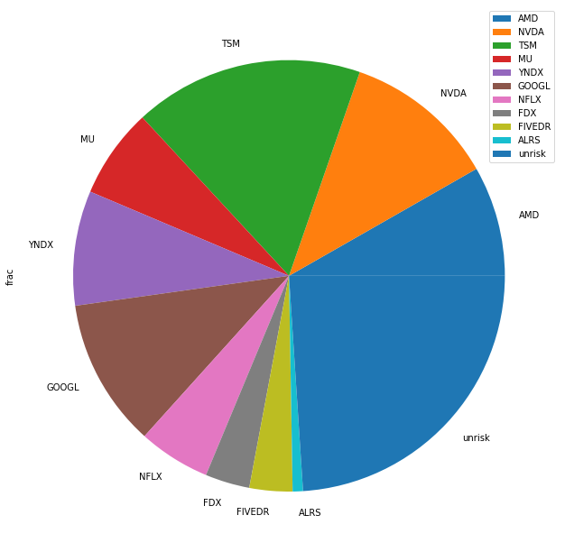

```python
df = pd.DataFrame(data = first_rebalance_frac.values(),
                  index=first_rebalance_frac.keys())
df.columns = ["frac"]
plot = df.plot.pie(y='frac', figsize=(15, 11))
```

### Проведем второй пересмотр портфеля

```python
second_rebalance = Get_investment_portfolio("./data_two",portfolio_income=40,
                                           unrisk_income=3.04,outliers=True,
                                           start_cash = 976307.507,
                                           confidence_level_interval=0.95,
                                           confidence_level_normal=0.01,
                                           last_income=True,
                                            start_portfolio=first_rebalance_frac,
                                            base_cash=1000000)
```

```python
second_rebalance_frac = second_rebalance.fit_trainsform()
```

```
['TSM.csv', 'ALRS.csv', 'AMD.csv', 'NVDA.csv', 'YNDX.csv', 'FDX.csv', 'NFLX.csv', 'FIVEDR.csv', 'GOOGL.csv', 'MU.csv']

Динамика акций за период:
В долях
{'TSM': -0.04081308559631571, 'ALRS': 0.07164389067524125, 'AMD': -0.07087918589516044, 'NVDA': -0.09136315578402432, 'YNDX': -0.018781683703149598, 'FDX': 0.010962671905697526, 'NFLX': -0.0416813584485479, 'FIVEDR': -0.0026503567787971457, 'GOOGL': 0.037172772279676185, 'MU': -0.028405987108051943}

В рублях
{'TSM': -3291.289664935271, 'ALRS': 7987.8866795088725, 'AMD': -11902.379580072908, 'NVDA': -6011.98124923734, 'YNDX': -1576.9560962396679, 'FDX': 1189.0965093802954, 'NFLX': -2193.397068069333, 'FIVEDR': -86.16585520495413, 'GOOGL': 1168.6042235713096, 'MU': -213.54393412148977}

Текущий капитал: 961377.381.
 Стартовый капитал: 976307.507.
 Разница c предыдущим периодом: -14930.126
 Общая разница: -38622.62

Все отлично, минимальное количество акций прошло проверку

Составленный портфель Тобина:
В долях
{'AMD': 0.085, 'NVDA': 0.1134, 'TSM': 0.1787, 'MU': 0.0714, 'YNDX': 0.0916, 'GOOGL': 0.1288, 'FDX': 0.0375, 'NFLX': 0.0519, 'FIVEDR': 0.035, 'ALRS': 0.0094, 'unrisk': 0.1973}

В рублях из  961377.381
{'AMD': 81717.07738500001, 'NVDA': 109020.1950054, 'TSM': 171798.1379847, 'MU': 68642.34500340001, 'YNDX': 88062.1680996, 'GOOGL': 123825.4066728, 'FDX': 36051.6517875, 'NFLX': 49895.48607390001, 'FIVEDR': 33648.208335, 'ALRS': 9036.947381400001, 'unrisk': 189679.7572713}
```

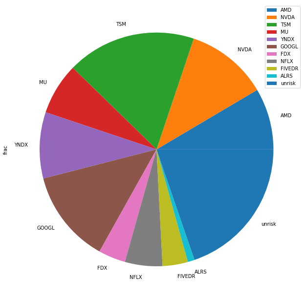

```python
df = pd.DataFrame(data = second_rebalance_frac.values(),
                  index=second_rebalance_frac.keys())
df.columns = ["frac"]
plot = df.plot.pie(y='frac', figsize=(15, 11))
```

## Пункт 4: Разберем каждый подпункт плана отдельно с кодом

### Получить котировки акций

```python
def __basic_load(self):
        """
        Метод отвечающий за загрузку данных из указанной директории
        """
        # Получаем имена всех фалов, находщихся в указанной директории
        all_files = [name for _,_,name in os.walk(self.data_dir_path)]

        if '.DS_Store' in all_files:
            index_del = all_files.index('.DS_Store')
            all_files.pop(index_del)
        print(all_files,end = "\n\n")

        # Генерируем словарь имен и значений полученных из фалов
        self.all_data = ({name[:-4]:pd.read_csv(self.data_dir_path+"/"+name)
                          .loc[:,["Дата","Цена"]] for name in all_files})
```

### Объединить все цены в одну таблицу по дате закрытия

```python
def __merge(self):
        """
        Метод отвечающий за объединение таблиц в одну
        """
        count = 0
        for dataset in self.all_data.values():
            if count == 0:
                self.total = dataset.copy()
            else:
                self.total = self.total.merge(dataset, on='Дата')
            count+= 1
        # Установим признак "Дата" как индекс во всей таблице
        self.total = self.total.set_index("Дата")
        self.total.columns = self.all_data.keys()
```

### Если передан специальный флаг, рассчитать доходность активов

```python
def __get_income_rebalance(self):
        """
        Метод отвечающий за вычисление доходность за период T1 и вычисление изменений капитала
        """
        # Вычисление текущих значений цен, выбранных акций и их обработка
        present_price = (self.total.iloc[0].apply(lambda x: x.replace(",", ".")))
        present_price = (present_price
                         .apply(lambda price: float(self.__format_data(price))))
        # Вычисление прошлых значений цен, выбранных акций и их обработка
        past_price = (self.total.iloc[1].apply(lambda x: x.replace(",", ".")))
        past_price = (past_price
                      .apply(lambda price: float(self.__format_data(price))))
        # Вычисление изменения цен в долях
        self.result_income_frac = ((present_price-past_price)/past_price).to_dict()
        # вычисление изменений вложений в каждую акцию
        self.result_income_value = ({delta[0]:delta[1]*self.start_cash*item_before[1]
                                     for delta,item_before
                                     in zip(self.result_income_frac.items(),
                                     self.start_portfolio.items())})
        # Вычисление разницы между стартовым капиталом и текущим
        delta = round(sum(self.result_income_value.values()),3)
        # Получение текущего капитала
        cur_cash = round(self.start_cash + delta,3)
        # Блок вывода
        print("Динамика акций за период:")
        print("В долях")
        print(self.result_income_frac,end = "\n\n")
        print("В рублях")
        print(self.result_income_value,end = "\n\n")
        print("Текущий капитал: {}.\n Стартовый капитал: {}.\n Разница: {}"
              .format(cur_cash,self.start_cash,delta),end = "\n\n")
        # Обновление значения капитала
        self.start_cash = cur_cash
```

### Вычислить еженедельную доходность

```python
def __calculate_income(self):
        """
        Метод вычисляющий еженедельную доходность в годовых процентах
        """
        total_week_per_year = 52
        count_weeks = self.total.shape[0]
        # Инициализир пустой датафрейм
        self.income_data = pd.DataFrame()
        # Сгенерируем  имена столбцов
        self.add_income_text = "Income_"
        new_labels_income = [self.add_income_text+name for name in self.total.columns]
        for new_label,old_label in zip(new_labels_income,self.total.columns):
            # Отформатируем стартовое значение
            for row in range(1,count_weeks):
                # Отформатируем текущее значение
                if "," in str(self.total.iloc[row-1][old_label]):
                    cur_val = self.total.iloc[row-1][old_label].replace(",", ".")
                    cur_val = self.__format_data(cur_val)
                else:
                    cur_val = self.total.iloc[row-1][old_label]


                if "," in str(self.total.iloc[row][old_label]):
                    #Отформатируем следующее значение
                    next_val = self.total.iloc[row][old_label].replace(",", ".")
                    next_val = self.__format_data(next_val)
                else:
                    next_val = self.total.iloc[row][old_label]
                # Вычислим недельную доходность
                self.income_data.loc[row-1,new_label] = (((float(cur_val)- float(next_val))
                                                         /float(next_val))
                                                         *100
                                                         *total_week_per_year)
```

## Проверить гипотезу о нормальном распределении

```python
def __check_normaltest(self):
        """
        Метод отвечающий за провекру гипотеза на нормальность выборки
        """
        # Инициализируем словарь для акций, прошедших проверку
        self.pass_shares = {}
        # Инициализируем словарь для акций, не прошедших проверку
        self.fail_shares = {}
        # Переберем все акции из нашей таблицы доходности
        for label in self.income_data.columns:
            # Получим для каждой выборки p-value
            _, p_value = st.normaltest(self.income_data[label])
            # Сравним найденное p-value с уровнем значимости
            if round(p_value,2) < self.confidence_level_normal:
                self.fail_shares[label] = round(p_value,3)
            else:
                self.pass_shares[label] = round(p_value,3)
        # Проверим все ли акции прошли проверку
        if len(self.pass_shares) >= 10:
            print("Все отлично, минимальное количество акций прошло проверку")
            top_best_shares = (self.income_data.describe()
                               .loc["mean",list(self.pass_shares.keys())]
                               .sort_values(ascending = False)
                               .head(len(self.pass_shares))
                               .index.tolist())
            self.income_data = self.income_data.loc[:,top_best_shares]
        else:
            # Выведем акции и их p-value, которые не прошли проверку
            print("Не все акции прошли проверку. Вот неподходящие акции")
            print(self.fail_shares,end = "\n\n")
```

## Вычислить интервальные оценки параметров

```python
def __get_confidence_interval(self):
        # Инициализируем индексы, которые в дальнейше преобразуем в мультииндекс
        pre_index = [("estimate_mean","left_side"),
                      ("estimate_mean","right_side"),
                      ("estimate_std","left_side"),
                      ("estimate_std","right_side")]
        list_index = np.empty(len(pre_index), dtype=object)
        list_index[:] = pre_index
        index = pd.MultiIndex.from_tuples(list_index)
        # Инициализируем фрейм, в который будем записывать найденные оценки
        self.period_estimate_table = pd.DataFrame(index = index)
        for label in self.income_data.columns:
            # Вычислим оценку среднего
            mean_estimate =  st.t.interval(self.confidence_level_interval,
                                           len(self.income_data[label])-1,
                                           self.income_data[label].mean(),
                                           self.income_data[label].sem())
            # Добавим найденные данные в таблицу
            self.period_estimate_table.loc[list_index[0],label] = mean_estimate[0]
            self.period_estimate_table.loc[list_index[1],label] = mean_estimate[1]
            # Вычислим оценку отклонения
            # Определим уровни
            p1 = (1 + self.confidence_level_interval)/2
            p2 = (1 - self.confidence_level_interval)/2
            # Найдем, интересующие нас значения
            value1 = chi2.ppf(p1, self.income_data.shape[0])
            value2 = chi2.ppf(p2, self.income_data.shape[0])
            pre_culc = self.income_data[label].std()*(self.income_data.shape[0])
            # Дополним таблицу, найденными знаениями
            self.period_estimate_table.loc[list_index[2],label] = (
                round((((pre_culc)/value1)**0.5),2))

            self.period_estimate_table.loc[list_index[3],label] = (
                round((((pre_culc)/value2)**0.5),2))
```

## Проверить гипотезу о равенстве коэффициента корреляции 0

```python
def __get_corr_mask(self):
        """
        Метод, который проверят гипотезу на равенство коэффициента коррелции равном 0
        """
        # Инициализируем пустой массив, а котором будет хранить маску
        self.corr_mask = []
        n = self.income_data.describe().loc["count"][0]
        # Переберем все коэффициенты
        for array, i in (zip(self.income_data.corr()
                             .values,range(0,len(self.income_data.corr())))):
                pre_corr = []
                for ind in range(len(array)):
                    if ind != i:
                        # Найдем наблюдаемое значение
                        t_nabl = (array[ind]*(n-2)**0.5)/(1-array[ind]**2)**0.5
                        # Сравним наблюдаемое значение с критическим
                        if st.t.ppf(1-0.05/2, n-2) < abs(t_nabl):
                            pre_corr.append(0)
                        else:
                            pre_corr.append(1)
                    else:
                        pre_corr.append(1)
                self.corr_mask.append(pre_corr)
```

## Трансформировать матрицу ковариации согласно результатам проверки гипотезы

```python
def __format_cov_matrix(self):
        """
        Метод, обрабатывающий матрицу ковариации, согласно найденной маске корреляции
        """
        self.total_cov = []
        for array_corr,array_cov in zip(self.corr_mask,
                                        self.income_data.cov().values):
            pre_cov = []
            for i in range(len(array_corr)):
                if array_corr[i] == 1:
                    pre_cov.append(array_cov[i])
                else:
                    pre_cov.append(0)
            self.total_cov.append(pre_cov)
```

## Решить задачу Тобина и получить оптимальный портфель

```python
def __solve_Tobin(self):
        """
        Метод, решающий задачу Тобина
        """
        # Получаем обратную матрицу ковариаций
        V_reverse = np.linalg.inv(self.total_cov)
        # Получаем вектор доходностей активов
        incomes_vector = self.income_data.describe().loc["mean",:].values
        # Преобразуем вектор доходностей с учетом безрискового актива
        ready_vector = incomes_vector - self.unrisk_income*np.ones(len(incomes_vector))
        # Решаем уравнение Тобина
        D = (ready_vector.T@V_reverse)@ready_vector
        self.portfolio_frac = (((self.portfolio_income-self.unrisk_income)/D)
                               .reshape(1,)*V_reverse@ready_vector)
        portfolio = {label[len(self.add_income_text):]:round(frac,4)
                     for label,frac in zip(self.income_data.columns,
                                           self.portfolio_frac)}
        portfolio["unrisk"] = round(1- sum(portfolio.values()),4)
        self.value_portfolio = {key:item*self.start_cash
                                for key,item in portfolio.items()}
        print("В долях")
        print(portfolio,end = "\n\n")
        print("В рублях из ",sum(self.value_portfolio.values()))
        print(self.value_portfolio,end = "\n\n")
        return(portfolio)
```